# Tipología y ciclo de vida de los datos: PRAC2 - Limpieza y análisis de datos

Autor: Eduardo Loza

Junio 2020

# 1 Descripción del dataset

El siguiente dataset que se va a utilizar extraído de Kaggle es “Titanic: Machine Learning from Disaster” , este dataset me parece bastante interesante ya que nos otorga datos sobre cuantas personas separadas por genero sobrevivieron al titanic, esta información es importante debido a que tomando tal catástrofe es necesario saber la mayor cantidad de información para tomar distintas conclusiones, por ejemplo utilizaremos este ejercicio y este dataset para responder a la pregunta si al momento de evacuar fueron primero las mujeres y niños o evacuaron por la clase a la que pertenecían las personas.

# 2 Integración y selección de los datos de interés a analizar.

En este apartado realizaremos el ingreso de los datos, y nos enfocaremos en los que van a ser mas necesarios analizar:

Primero vamos a cargar los datos:

```r
data<-read.csv("./titanic.csv",header=T,sep=",")
attach(data)
```

utilizamos en la funcion read el sep=“,” debido a que es el separador por el cual esta dividido el data set, asi que empezaremos haciendo un breve análisis de los datos ya que nos interesa tener una idea general de los datos que disponemos. Por ello, primero calcularemos las dimensiones de nuestra base de datos y analizaremos qué tipos de atributos tenemos.

```r
dim(data)
```

```
## [1] 2201    4
```

Para lograr calcular las dimensiones de la base de datos utilizamos la función dim(). Obtenemos que disponemos de 2201 registros o pasajeros (filas) y 4 variables (columnas).

Ahora vamos a utilizar la función str() y podemos observar que tenemos cuatro variables categóricas o discretas, es decir, toman valores en un conjunto finito. La variable CLASS hace referencia a la clase en la que viajaban los pasajeros (1ª, 2ª, 3ª o crew), AGE determina si era adulto o niño (Adulto o Menor), la variable SEX si era hombre o mujer (Hombre o Mujer) y la última variable (SURVIVED) informa si el pasajero murió o sobrevivió en el accidente (Muere o Sobrevive).

```r
str(data)
```

```
## 'data.frame':    2201 obs. of  4 variables:
##  $ CLASS   : Factor w/ 4 levels "1a","2a","3a",..: 1 1 1 1 1 1 1 1 1 1 ...
##  $ AGE     : Factor w/ 2 levels "Adulto","Menor": 1 1 1 1 1 1 1 1 1 1 ...
##  $ SEX     : Factor w/ 5 levels "","H","Hombre",..: 3 3 3 3 3 3 3 3 3 3 ...
##  $ SURVIVED: Factor w/ 2 levels "Muere","Sobrevive": 2 2 2 2 2 2 2 2 2 2 ...
```

# 3 Limpieza de los datos.

## 3.1 ¿Los datos contienen ceros o elementos vacíos? ¿Cómo gestionarías cada uno de estos casos?

ya que nos interesa saber si existen valores nulos (elementos vacíos) es recomendable empezar el análisis con una visión general de las variables. Mostraremos para cada atributo la cantidad de valores perdidos mediante la función summary.

```r
summary(data)
```

```
##   CLASS         AGE           SEX            SURVIVED
##  1a  :325   Adulto:2092         :   3   Muere    :1490
##  2a  :285   Menor : 109   H     :   4   Sobrevive: 711
##  3a  :706                 Hombre:1724
##  crew:885                 M     :   7
##                           Mujer : 463
```

Como podemos observar tenemos valores vacios, y en el caso de SEX tenemos datos que necesitan ser normalizados tambien, asi que primero realizaremos un summary solo de SEX, y luego vamos a normalizar estos datos, debido a que la cantidad de hombres es mucho mayor al de mujeres, los datos vacios que tenemos los ubicaremos con el valor de Hombre de la siguiente manera:

```r
summary(data$SEX)
```

```
##             H Hombre      M  Mujer
##      3      4   1724      7    463
```

```r
# Al tener muchos valores distintos vamos a normalizar reemplazando el valor erroneo con el correcto
data$SEX <- as.character(data$SEX)
data$SEX[data$SEX == 'H'] <- "Hombre"
data$SEX[data$SEX == ''] <- "Hombre"
data$SEX[data$SEX == 'M'] <- "Mujer"
data$SEX <- as.factor(data$SEX)
summary(data$SEX)
```

```
## Hombre  Mujer
##   1731    470
```

De esta manera podemos observar que los datos ahora estan correctos sin datos vacios o sin normalizar.

## 3.2 Identificación y tratamiento de valores extremos.

Para visualizar los valores extremos podemos utilizar el comando summary y obtenemos los siguientes datos:.

```r
summary(data)
```

```
##   CLASS         AGE           SEX            SURVIVED
##  1a  :325   Adulto:2092   Hombre:1731   Muere    :1490
##  2a  :285   Menor : 109   Mujer : 470   Sobrevive: 711
##  3a  :706
##  crew:885
```

Al no tener valores numéricos o distintos valores que nos permite calcular extremos, no podemos realizar un tratamiento de los mismos.

# 4 Análisis de los datos.

Aprovechando que tenemos distintos paquetes al utilizar R, vamos a utilizarggplot2, gridExtra y grid de R. Para poder obtener una mejor visualizació de los datos y poder analizar los datos de mejor manera.

```r
if(!require(ggplot2)){
    install.packages('ggplot2', repos='http://cran.us.r-project.org')
    library(ggplot2)
}
if(!require(grid)){
    install.packages('grid', repos='http://cran.us.r-project.org')
    library(grid)
}
if(!require(gridExtra)){
    install.packages('gridExtra', repos='http://cran.us.r-project.org')
    library(gridExtra)
}
```

## 4.1 Selección de los grupos de datos que se quieren analizar/comparar (planificación de los análisis a aplicar).

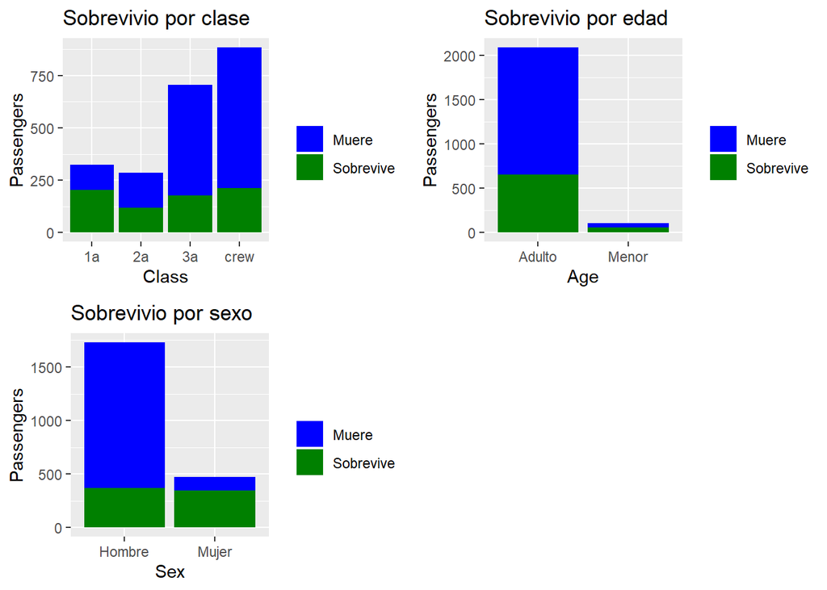

```r
grid.newpage()
plotbyClass<-ggplot(data,aes(CLASS,fill=SURVIVED))+geom_bar() +labs(x="Class", y="Passengers")+ guides(fill=guide_legend(title=""))+ scale_fill_manual(values=c("blue","#008000"))+ggtitle("Sobrevivio por clase")
plotbyAge<-ggplot(data,aes(AGE,fill=SURVIVED))+geom_bar() +labs(x="Age", y="Passengers")+ guides(fill=guide_legend(title=""))+ scale_fill_manual(values=c("blue","#008000"))+ggtitle("Sobrevivio por edad")
plotbySex<-ggplot(data,aes(SEX,fill=SURVIVED))+geom_bar() +labs(x="Sex", y="Passengers")+ guides(fill=guide_legend(title=""))+ scale_fill_manual(values=c("blue","#008000"))+ggtitle("Sobrevivio por sexo")
grid.arrange(plotbyClass,plotbyAge,plotbySex,ncol=2)
```

## 4.2 Comprobación de la normalidad y homogeneidad de la varianza.

para la homogeneidad de varianza o homocedasticidad tenemos que tener en cuenta que si los grupos con tamaños muestrales pequeños son los que tienen mayor varianza, la probabilidad real de cometer errores de hipotesis sera menor, para realizar un grafico sobre este test de varianza utilizaremos el ggplot

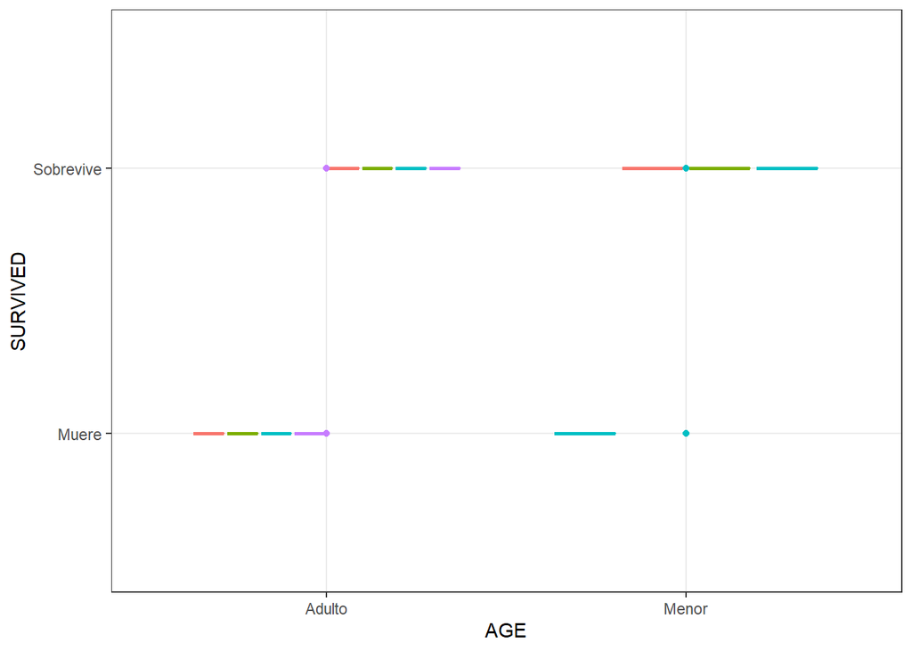

```r
ggplot(data, aes(x = AGE, y = SURVIVED, colour = CLASS)) +
  geom_boxplot() +
  geom_point() +
  theme_bw() +
  theme(legend.position = "none")
```

podemos tener en cuenta la homogeneidad de la varianza es mucho menor ya que estamos calculando entre valores discretos.

## 4.3 Aplicación de pruebas estadísticas para comparar los grupos de datos. En función de los datos y el objetivo del estudio, aplicar pruebas de contraste de hipótesis, correlaciones, regresiones, etc. Aplicar al menos tres métodos de análisis diferentes.

para responder a la pregunta inicial y tener valores estadicticos reales utilizando variables discretas la mejor manera es mediante un arbol de decisiones, el cual toma en cuenta cada hipótesis para poder analizar qué tipo de pasajero del Titanic tenía probabilidades de sobrevivir o no. Por lo tanto, la variable por la que clasificaremos es el campo de si el pasajero sobrevivió o no. De todas maneras, al imprimir las primeras (con head) y últimas 10 (con tail) filas nos damos cuenta de que los datos están ordenados.

```r
head(data,10)
```

```
##    CLASS    AGE    SEX  SURVIVED
## 1     1a Adulto Hombre Sobrevive
## 2     1a Adulto Hombre Sobrevive
## 3     1a Adulto Hombre Sobrevive
## 4     1a Adulto Hombre Sobrevive
## 5     1a Adulto Hombre Sobrevive
## 6     1a Adulto Hombre Sobrevive
## 7     1a Adulto Hombre Sobrevive
## 8     1a Adulto Hombre Sobrevive
## 9     1a Adulto Hombre Sobrevive
## 10    1a Adulto Hombre Sobrevive
```

```r
tail(data,10)
```

```
##      CLASS    AGE   SEX  SURVIVED
## 2192  crew Adulto Mujer Sobrevive
## 2193  crew Adulto Mujer Sobrevive
## 2194  crew Adulto Mujer Sobrevive
## 2195  crew Adulto Mujer Sobrevive
## 2196  crew Adulto Mujer Sobrevive
## 2197  crew Adulto Mujer Sobrevive
## 2198  crew Adulto Mujer Sobrevive
## 2199  crew Adulto Mujer     Muere
## 2200  crew Adulto Mujer     Muere
## 2201  crew Adulto Mujer     Muere
```

Una de las tecnicas utilizadas en el proceso estadistico para estimar las relaciones entre los datos es la regresión, por lo que es necesario realizar un data_random para poder obtener datos que podamos utilizar en el proceso.

```r
set.seed(1)
data_random <- data[sample(nrow(data)),]
```

Ahora vamos a proceder a creas dos conjuntos de datos, uno de entrenamiento y uno de pruebas, utilizando el campo de si la persona sobrevivio como variable de clasificación

```r
set.seed(666)
y <- data_random[,4]
X <- data_random[,1:3]
```

Podemos elegir el subconjunto de entrenamiento y de prueba de diversas maneras. La primer opción consiste en calcular a cuántas filas corresponde dos tercios de los datos (2*2201/3=1467) y dividir “manualmente” el conjunto.

```r
trainX <- X[1:1467,]
trainy <- y[1:1467]
testX <- X[1468:2201,]
testy <- y[1468:2201]
```

En la segunda opción podemos crear directamente un rango.

```r
indexes = sample(1:nrow(data), size=floor((2/3)*nrow(data)))
trainX<-X[indexes,]
trainy<-y[indexes]
testX<-X[-indexes,]
testy<-y[-indexes]
```

Con esto tenemos los datos suficientes y necesarios para realizar un arbol de decisiones

# 5 Representación de los resultados a partir de tablas y gráficas.

Se crea el árbol de decisión usando los datos de entrenamiento:

```r
model <- C50::C5.0(trainX, trainy,rules=TRUE )
summary(model)
```

```
##
## Call:
## C5.0.default(x = trainX, y = trainy, rules = TRUE)
##
##
## C5.0 [Release 2.07 GPL Edition]      Tue Jun 09 16:39:41 2020
## -------------------------------
##
## Class specified by attribute `outcome'
##
## Read 1467 cases (4 attributes) from undefined.data
##
## Rules:
##
## Rule 1: (1169/255, lift 1.2)
##  SEX = Hombre
##  ->  class Muere  [0.781]
##
## Rule 2: (20, lift 2.9)
##  CLASS in {1a, 2a}
##  AGE = Menor
##  ->  class Sobrevive  [0.955]
##
## Rule 3: (298/75, lift 2.3)
##  SEX = Mujer
##  ->  class Sobrevive  [0.747]
##
## Default class: Muere
##
##
## Evaluation on training data (1467 cases):
##
##          Rules
##    ----------------
##      No      Errors
##
##       3  317(21.6%)   <<
##
##
##     (a)   (b)    <-classified as
##    ----  ----
##     914    75    (a): class Muere
##     242   236    (b): class Sobrevive
##
##
##  Attribute usage:
##
##  100.00% SEX
##    1.36% CLASS
##    1.36% AGE
##
##
## Time: 0.0 secs
```

A continuación mostramos el árbol obtenido.

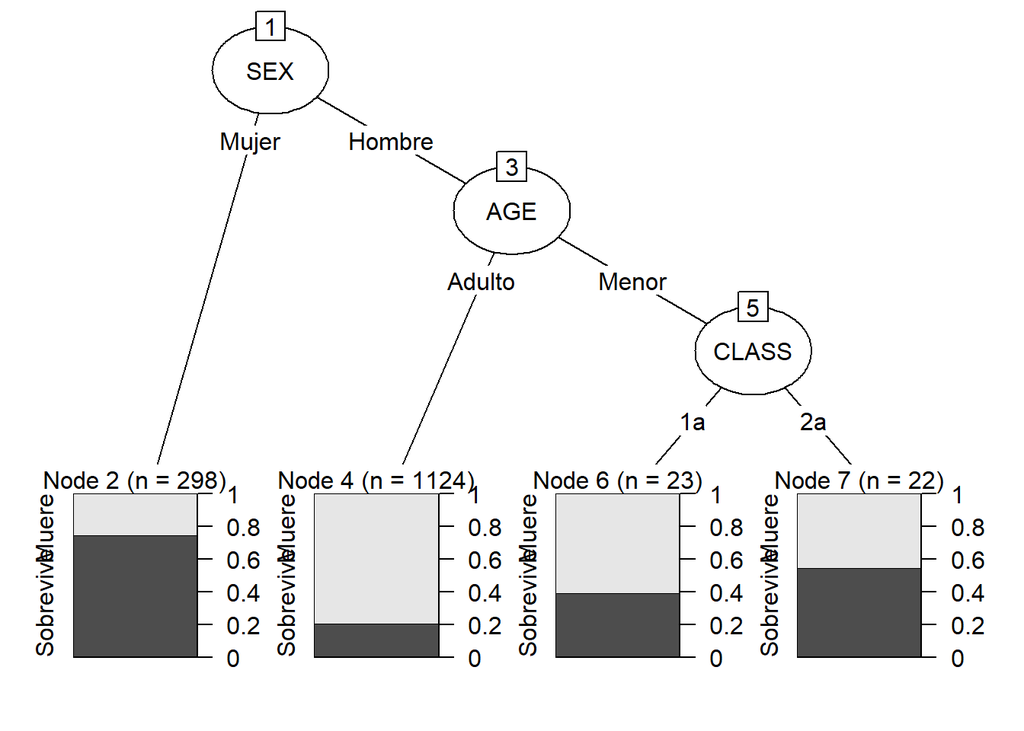

```r
model <- C50::C5.0(trainX, trainy)
plot(model)
```

Una vez tenemos el modelo, podemos comprobar su calidad prediciendo la clase para los datos de prueba que nos hemos reservado al principio.

```r
predicted_model <- predict( model, testX, type="class" )
print(sprintf("La precisión del árbol es: %.4f %%",100*sum(predicted_model == testy) / length(predicted_model)))
```

```
## [1] "La precisión del árbol es: 78.2016 %"
```

Cuando hay pocas clases, la calidad de la predicción se puede analizar mediante una matriz de confusión que identifica los tipos de errores cometidos.

```r
mat_conf<-table(testy,Predicted=predicted_model)
mat_conf
```

```
##            Predicted
## testy       Muere Sobrevive
##   Muere       450        51
##   Sobrevive   109       124
```

# 6 Resolución del problema. A partir de los resultados obtenidos, ¿cuáles son las conclusiones? ¿Los resultados permiten responder al problema?

A partir del árbol de decisión que generamos, se pueden extraer las siguientes reglas de decisión: